# Statistical Analysis: Valence Processing

We plot again to visualize what the data looks like now.

```r
# Remove participant from the dataset
filtered_df <- subset(pre_filtered_df, !(Participant %in% c("2400")))
filtered_df
```

```
## # A tibble: 1,440 × 10
##    Accuracy Condition Emotional_valence_cat Emotional_valence_cont Item_type
##       <dbl> <chr>     <chr>                 <chr>                  <chr>
##  1        1 word      negative              2.74                   exp
##  2        1 word      negative              2.18                   exp
##  3        1 word      negative              1.9                    exp
##  4        1 word      positive              7.24                   exp
##  5        1 word      neutral               5.02                   exp
##  6        1 word      neutral               5.5                    exp
##  7        1 word      neutral               5.18                   exp
##  8        1 word      neutral               5.48                   exp
##  9        1 word      positive              7.11                   exp
## 10        1 word      neutral               4.81                   exp
## # ℹ 1,430 more rows
## # ℹ 5 more variables: Length <dbl>, Lg10SUBTLEX_US <chr>, Participant <dbl>,
## #   RT <dbl>, Stimulus <chr>
```

```r
# Plot again:
means_by_participant <- filtered_df %>%
  group_by(Participant) %>%
  summarise(
    mean_RT = mean(RT, na.rm = TRUE),
    mean_acc = mean(Accuracy, na.rm = TRUE)
  )
means_by_participant
```

```
## # A tibble: 16 × 3
##    Participant mean_RT mean_acc
##          <dbl>   <dbl>    <dbl>
##  1        1001    664.    0.978
##  2        1002   1224.    0.956
##  3        1003    866.    0.989
##  4        1004    687.    0.978
##  5        1005    750.    0.989
##  6        1006    747.    0.978
##  7        1007    779.    1
##  8        1008    907.    0.978
##  9        1009    847.    0.989
## 10        2000    971.    0.967
## 11        2100    630.    0.989
## 12        2200    693.    1
## 13        2300    690.    0.989
## 14        2500    657.    0.967
## 15        2600    748.    0.944
## 16        2700    648.    0.967
```

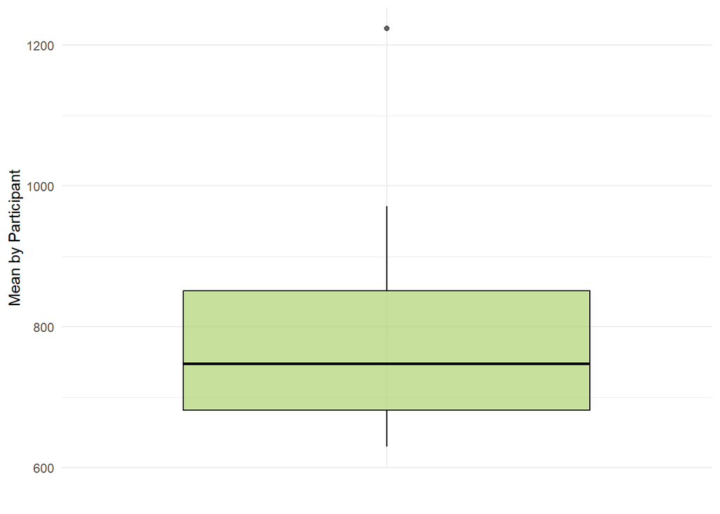

```r
plot_outliers(mean_RT, "average_RT_filtered.png", "darkolivegreen3")
```

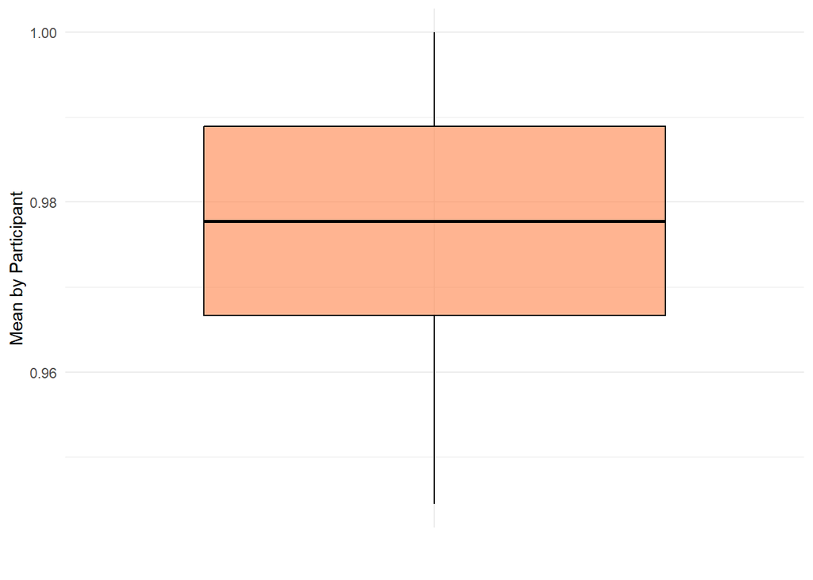

```r
plot_outliers(mean_acc, "average_acc_filtered.png", "sienna1")
```

### Reaction Time Filtering

To remove implausible reaction times, a cutoff is applied.

Only trials with reaction times between **200 ms and 2000 ms** are retained.

This removes extremely fast responses (likely accidental key presses) and extremely slow responses that may reflect distractions or interruptions.

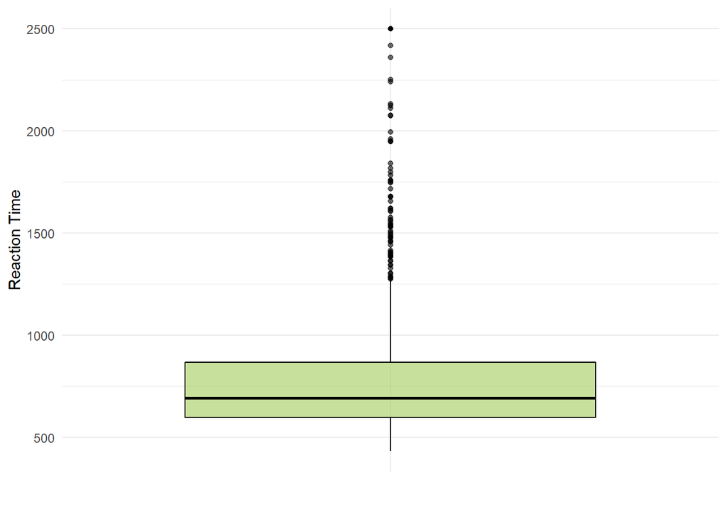

```r
# Visualize the distribution of reaction times to see where to place the cutoff
p <- ggplot(data = filtered_df, aes(x = "", y = RT)) +
  geom_boxplot(fill = "darkolivegreen3", color = "black", alpha = 0.6) +
  labs(
    x = "",
    y = "Reaction Time"
  ) +
  theme_minimal()

#ggsave(
#  "RT_distribution.png",
#  plot = last_plot(),
#  width = 7,
#  height = 5
#)

p
```

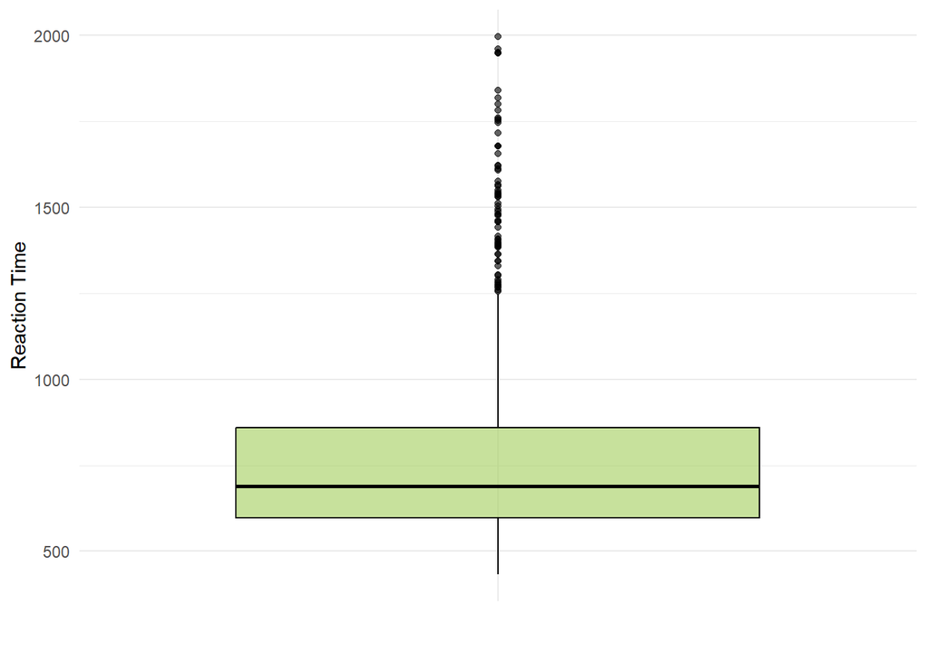

```r
# Apply cutoff
post_filtered_df <- filtered_df %>%
  filter(RT >= 200 & RT <= 2000)

# Plot again to visualize the new distribution
p <- ggplot(data = post_filtered_df, aes(x = "", y = RT)) +
  geom_boxplot(fill = "darkolivegreen3", color = "black", alpha = 0.6) +
  labs(
    x = "",
    y = "Reaction Time"
  ) +
  theme_minimal()

#ggsave(
#  "RT_outlier.png",
#  plot = last_plot(),
#  width = 7,
#  height = 5
#)

p
```

### Mean Accuracy and Reaction Time by Valence Condition

Next, mean accuracy and reaction time are computed for each emotional valence category:

- positive
- neutral
- negative

```r
# Mean accuracy and reaction times by valence condition
means_by_valence <- post_filtered_df %>%
  group_by(Emotional_valence_cat) %>%
  summarise(
    mean_RT = mean(RT, na.rm = TRUE),
    mean_acc = mean(Accuracy, na.rm = TRUE)
  )
means_by_valence
```

```
## # A tibble: 3 × 3
##   Emotional_valence_cat mean_RT mean_acc
##   <chr>                   <dbl>    <dbl>
## 1 negative                 786.    0.985
## 2 neutral                  771.    0.977
## 3 positive                 732.    0.994
```

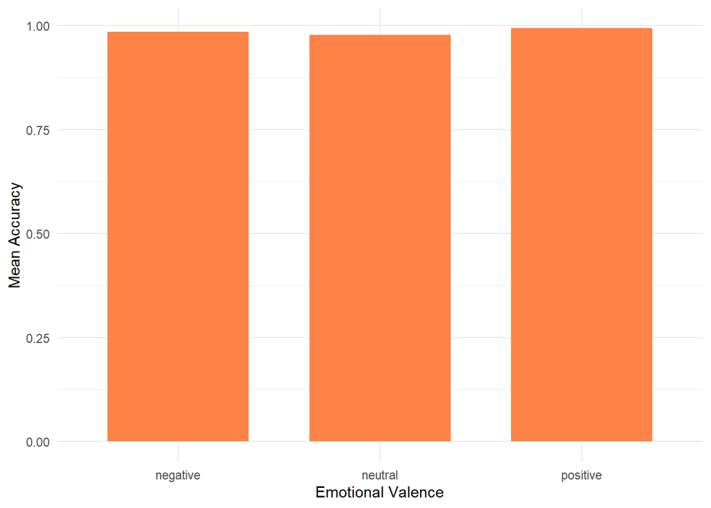

```r
# Plot mean accuracies (barplots)
plot_valence <- function(y_axis, filename, colour){
  p <- ggplot(data = means_by_valence, aes(x = Emotional_valence_cat, y = {{ y_axis }}, fill = Emotional_valence_cat)) +
    geom_col(fill = colour, width = 0.7) +
    labs(
      x = "Emotional Valence",
      y = "Mean Accuracy"
    ) +
    theme_minimal()

ggsave(
  filename,
  plot = last_plot(),
  width = 7,
  height = 5
)

p
}

plot_valence(mean_acc, "average_acc_per_valence_barplot.png", "sienna1")
```

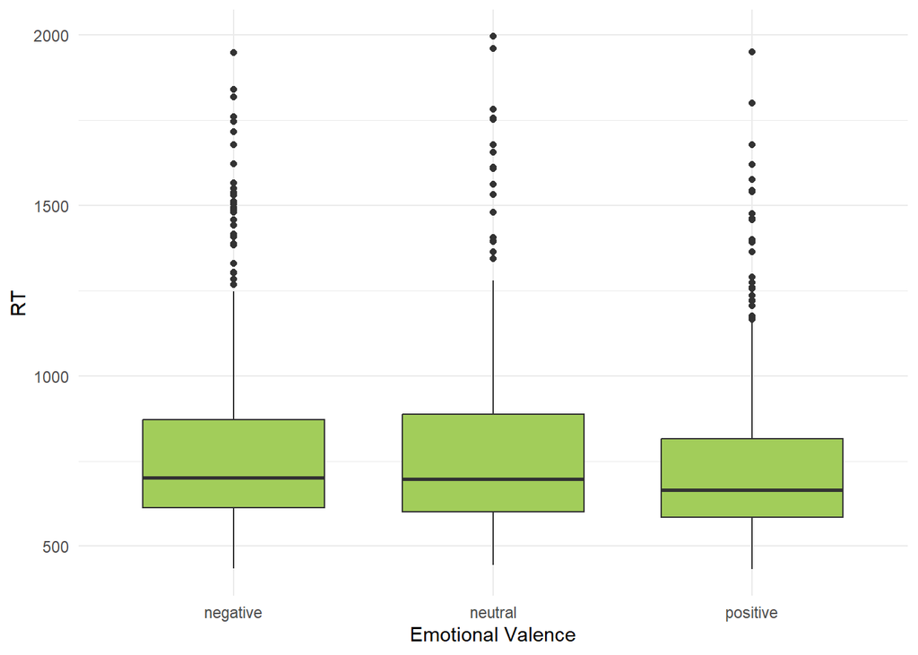

```r
# Plot mean RTs (boxplots)
plot_valence <- function(data, y_axis, filename, colour){

  p <- ggplot(data = data,
              aes(x = Emotional_valence_cat,
                  y = {{ y_axis }},
                  fill = Emotional_valence_cat)) +
    geom_boxplot(fill = colour, width = 0.7) +
    labs(
      x = "Emotional Valence",
      y = "RT"
    ) +
    theme_minimal()

  ggsave(
    filename,
    plot = p,
    width = 7,
    height = 5
  )

  # anzeigen
  p
}

plot_valence(post_filtered_df, RT, "RT_per_valence_boxplot.png", "darkolivegreen3")
```

# Inferential Statistics

To formally test the research questions, mixed-effects models are used.

Mixed-effects models are appropriate for experimental data because they allow us to account for variability across both:

- participants
- stimuli

## Data Loading and Preparation

- Data loading: The full experimental dataset containing reaction times and accuracy values as well as participant data is loaded from a CSV file.
- Filtering: everything that was removed from the above dataset needs to be removed here as well (practice items, nonwords, certain participants)
- Variable coding: Before fitting the models, variables are converted to appropriate types (e.g., numeric or factor). The ordering of factor levels is also specified for interpretability.

```r
# Load dataset
inf_df <- read_csv("LDT_longlist_merged_2026_01_09.csv", show_col_types = FALSE, col_types = cols(
                          lex_tale_result = col_character()
                        )) %>%
  mutate(lex_tale_result = as.numeric(str_replace(lex_tale_result, ",", ".")))    # make sure LexTALE gets parsed right

# Filtering
prepped_df <- subset(inf_df, Item_type == "exp" & Condition == "word" & !(Participant %in% c("2400")) & RT >= 200 & RT <= 2000)

# Variable coding
prepped_df <- prepped_df %>%
  mutate(
    Accuracy = as.numeric(Accuracy),
    Participant = as.factor(Participant),
    Emotional_valence_cat = factor(Emotional_valence_cat, levels = c("neutral", "positive", "negative")),
    Length = as.numeric(Length),
    RT = as.numeric(RT),
    Stimulus = as.factor(Stimulus),
    lex_tale_result = as.numeric(lex_tale_result),
  )
```

### Standardizing Continuous Predictors

Continuous predictors are standardized (z-transformed). This improves model convergence and ensures that predictors are on comparable scales.

```r
prepped_df <- prepped_df %>%
  mutate(
    lex_tale_z = scale(lex_tale_result),
    Length_z   = scale(Length)
  )
```

## Accuracy Analysis

Accuracy is analysed using a **generalized linear mixed-effects model** with a binomial link function.

The model includes:

Fixed effects:

- LexTALE score (standardized)
- emotional valence
- word length

Random effects:

- random intercepts for participants
- random intercepts for stimuli

```r
# Accuracy mixed model
acc_model <- glmer(Accuracy ~ lex_tale_z * Emotional_valence_cat + Length_z + (1| Participant) + (1| Stimulus), family = binomial, data = prepped_df, control = glmerControl(optimizer = "bobyqa", optCtrl = list(maxfun = 1e5)))
summary(acc_model)
```

```
## Generalized linear mixed model fit by maximum likelihood (Laplace
##   Approximation) [glmerMod]
##  Family: binomial  ( logit )
## Formula: Accuracy ~ lex_tale_z * Emotional_valence_cat + Length_z + (1 |
##     Participant) + (1 | Stimulus)
##    Data: prepped_df
## Control: glmerControl(optimizer = "bobyqa", optCtrl = list(maxfun = 1e+05))
##
##       AIC       BIC    logLik -2*log(L)  df.resid
##     219.1     266.4    -100.5     201.1      1414
##
## Scaled residuals:
##      Min       1Q   Median       3Q      Max
## -10.3722   0.0583   0.0754   0.1024   0.6689
##
## Random effects:
##  Groups      Name        Variance Std.Dev.
##  Stimulus    (Intercept) 1.4793   1.2163
##  Participant (Intercept) 0.4523   0.6725
## Number of obs: 1423, groups:  Stimulus, 90; Participant, 16
##
## Fixed effects:
##                                          Estimate Std. Error z value Pr(>|z|)
## (Intercept)                               4.95595    0.67284   7.366 1.76e-13
## lex_tale_z                               -0.05112    0.35007  -0.146    0.884
## Emotional_valence_catpositive             0.93416    0.80412   1.162    0.245
## Emotional_valence_catnegative             0.02316    0.68000   0.034    0.973
## Length_z                                  0.39914    0.31677   1.260    0.208
## lex_tale_z:Emotional_valence_catpositive -0.20690    0.61630  -0.336    0.737
## lex_tale_z:Emotional_valence_catnegative  0.15490    0.46803   0.331    0.741
##
## (Intercept)                              ***
## lex_tale_z
## Emotional_valence_catpositive
## Emotional_valence_catnegative
## Length_z
## lex_tale_z:Emotional_valence_catpositive
## lex_tale_z:Emotional_valence_catnegative
## ---
## Signif. codes:  0 '***' 0.001 '**' 0.01 '*' 0.05 '.' 0.1 ' ' 1
##
## Correlation of Fixed Effects:
##                        (Intr) lx_tl_ Emtnl_vlnc_ctp Emtnl_vlnc_ctn Lngth_
## lex_tale_z             -0.026
## Emtnl_vlnc_ctp         -0.441  0.007
## Emtnl_vlnc_ctn         -0.536  0.010  0.424
## Length_z                0.236 -0.001 -0.233         -0.329
## lx_tl_z:Emtnl_vlnc_ctp  0.011 -0.422 -0.156         -0.006         -0.002
## lx_tl_z:Emtnl_vlnc_ctn -0.003 -0.549 -0.008          0.046         -0.003
##                        lx_tl_z:Emtnl_vlnc_ctp
## lex_tale_z
## Emtnl_vlnc_ctp
## Emtnl_vlnc_ctn
## Length_z
## lx_tl_z:Emtnl_vlnc_ctp
## lx_tl_z:Emtnl_vlnc_ctn  0.310
```

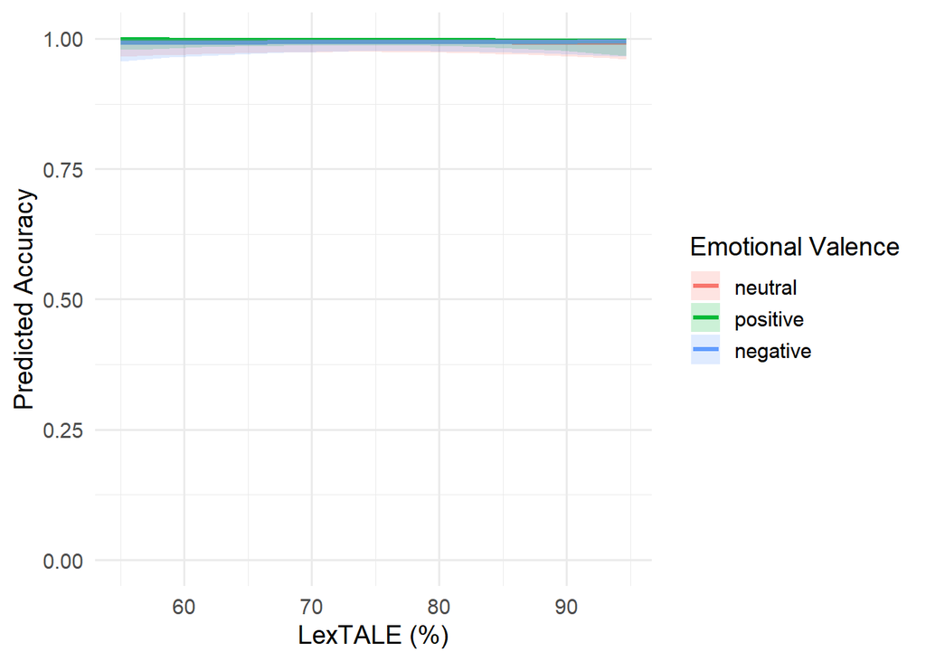

```r
# Plot the model
# LexTALE (standardized)
lex_seq_z <- seq(min(prepped_df$lex_tale_z, na.rm = TRUE),
                 max(prepped_df$lex_tale_z, na.rm = TRUE),
                 by = 0.1)

# emmeans (standardized, length fixed to zero)
emm <- emmeans(
  acc_model,
  ~ lex_tale_z | Emotional_valence_cat,
  at = list(lex_tale_z = lex_seq_z, Length_z = 0),
  type = "response"
)

# Convert to dataframe
emm_df <- as.data.frame(emm)

# Backtransformation to original range (0–100%)
lex_mean <- mean(prepped_df$lex_tale_result)
lex_sd   <- sd(prepped_df$lex_tale_result)
emm_df$lex_tale_pct <- emm_df$lex_tale_z * lex_sd + lex_mean


# Plot
p <- ggplot(emm_df, aes(x = lex_tale_pct,
                   y = prob,
                   color = Emotional_valence_cat,
                   fill = Emotional_valence_cat)) +
  geom_line(linewidth = 1.2) +                     # Linie für geschätzte acc
  geom_ribbon(aes(ymin = asymp.LCL, ymax = asymp.UCL),
              alpha = 0.2, color = NA) +           # CI bänder
  labs(x = "LexTALE (%)",
       y = "Predicted Accuracy",
       color = "Emotional Valence",
       fill = "Emotional Valence") +
  scale_y_continuous(limits = c(0, 1)) +
  theme_minimal(base_size = 14)

ggsave(
  "acc_model.png",
  plot = last_plot(),
  width = 7,
  height = 5
)

p
```

## Reaction Time Analysis

Reaction times are analysed using a **linear mixed-effects model**.

Only trials with correct responses are included, as incorrect trials may reflect different cognitive processes.

The model includes:

Fixed effects:

- LexTALE score (standardized)
- emotional valence
- word length

Random effects:

- random intercepts for participants
- random intercepts for stimuli

```r
# Filter incorrect trials
RT_df <- subset(prepped_df, Accuracy == "1")

# RT mixed model
RT_model <- lmer(RT ~ lex_tale_z * Emotional_valence_cat + Length_z + (1| Participant) + (1| Stimulus), data = RT_df)
summary(RT_model)
```

```
## Linear mixed model fit by REML. t-tests use Satterthwaite's method [
## lmerModLmerTest]
## Formula:
## RT ~ lex_tale_z * Emotional_valence_cat + Length_z + (1 | Participant) +
##     (1 | Stimulus)
##    Data: RT_df
##
## REML criterion at convergence: 18774.4
##
## Scaled residuals:
##     Min      1Q  Median      3Q     Max
## -2.1115 -0.5783 -0.1740  0.2979  5.4590
##
## Random effects:
##  Groups      Name        Variance Std.Dev.
##  Stimulus    (Intercept)  6170     78.55
##  Participant (Intercept) 18142    134.69
##  Residual                35222    187.68
## Number of obs: 1402, groups:  Stimulus, 90; Participant, 16
##
## Fixed effects:
##                                          Estimate Std. Error       df t value
## (Intercept)                               782.071     37.858   21.148  20.658
## lex_tale_z                                -30.235     34.876   15.252  -0.867
## Emotional_valence_catpositive             -54.594     24.352   83.616  -2.242
## Emotional_valence_catnegative              -4.078     24.744   83.960  -0.165
## Length_z                                   30.544     10.150   84.060   3.009
## lex_tale_z:Emotional_valence_catpositive  -11.148     12.314 1294.395  -0.905
## lex_tale_z:Emotional_valence_catnegative  -14.861     12.396 1295.237  -1.199
##                                          Pr(>|t|)
## (Intercept)                              1.67e-15 ***
## lex_tale_z                                0.39942
## Emotional_valence_catpositive             0.02761 *
## Emotional_valence_catnegative             0.86948
## Length_z                                  0.00346 **
## lex_tale_z:Emotional_valence_catpositive  0.36545
## lex_tale_z:Emotional_valence_catnegative  0.23080
## ---
## Signif. codes:  0 '***' 0.001 '**' 0.01 '*' 0.05 '.' 0.1 ' ' 1
##
## Correlation of Fixed Effects:
##                        (Intr) lx_tl_ Emtnl_vlnc_ctp Emtnl_vlnc_ctn Lngth_
## lex_tale_z              0.005
## Emtnl_vlnc_ctp         -0.331  0.000
## Emtnl_vlnc_ctn         -0.332  0.000  0.532
## Length_z                0.109  0.001 -0.227         -0.282
## lx_tl_z:Emtnl_vlnc_ctp  0.000 -0.179  0.002          0.001         -0.002
## lx_tl_z:Emtnl_vlnc_ctn  0.000 -0.178  0.001         -0.001         -0.002
##                        lx_tl_z:Emtnl_vlnc_ctp
## lex_tale_z
## Emtnl_vlnc_ctp
## Emtnl_vlnc_ctn
## Length_z
## lx_tl_z:Emtnl_vlnc_ctp
## lx_tl_z:Emtnl_vlnc_ctn  0.504
```

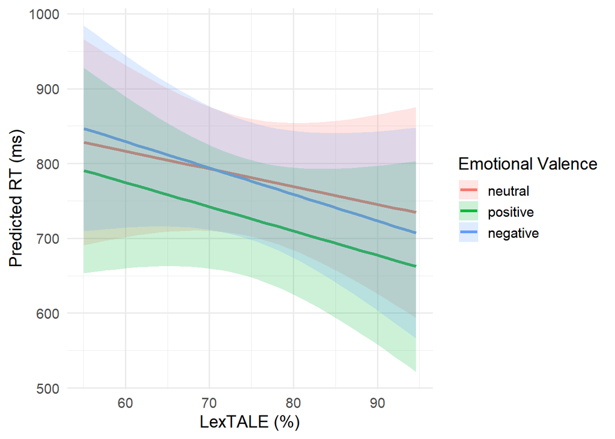

```r
# Plot the model
# LexTALE (standardized)
lex_seq_z <- seq(min(RT_df$lex_tale_z, na.rm = TRUE),
                 max(RT_df$lex_tale_z, na.rm = TRUE),
                 by = 0.1)

# emmeans (standardized, length fixed to zero)
emm <- emmeans(
  RT_model,
  ~ lex_tale_z | Emotional_valence_cat,
  at = list(lex_tale_z = lex_seq_z, Length_z = 0)
)

# Convert to dataframe
emm_df <- as.data.frame(emm)

# Backtransformation to original range (0-100%)
lex_mean <- mean(RT_df$lex_tale_result)
lex_sd   <- sd(RT_df$lex_tale_result)
emm_df$lex_tale_pct <- emm_df$lex_tale_z * lex_sd + lex_mean


# Plot
p <- ggplot(emm_df, aes(x = lex_tale_pct,
                   y = emmean,
                   color = Emotional_valence_cat,
                   fill = Emotional_valence_cat)) +
  geom_line(linewidth = 1.2) +
  geom_ribbon(aes(ymin = lower.CL, ymax = upper.CL),
              alpha = 0.2, color = NA) +
  labs(x = "LexTALE (%)",
       y = "Predicted RT (ms)",
       color = "Emotional Valence",
       fill = "Emotional Valence") +
  theme_minimal(base_size = 14)

ggsave(
  "RT_model.png",
  plot = last_plot(),
  width = 7,
  height = 5
)

p
```

# Interpretation

The results of the mixed-effects models are interpreted with respect to the research questions:

1. Does English proficiency influence the **accuracy or speed** of lexical decisions?
2. Do **emotionally valenced words** (positive or negative) show a processing advantage compared to neutral words?
3. Does **emotional valence interact with English proficiency** in predicting reaction times or accuracy?

The answers to these questions are based on the inferential statistical results reported above.

# Additional Analyses

Post-hoc, we decided to additionally examine whether participants’ overall performance in the lexical decision task correlates with their LexTALE scores.

```r
lex_by_participant <- prepped_df %>%
  group_by(Participant) %>%
  summarise(lex_tale_result = first(lex_tale_result))

means_by_participant$Participant <- as.character(means_by_participant$Participant)
lex_by_participant$Participant   <- as.character(lex_by_participant$Participant)

corr_df <- left_join(means_by_participant, lex_by_participant, by = "Participant")

# Accuracy

# Pearson
cor.test(corr_df$mean_acc,
         corr_df$lex_tale_result,
         method = "pearson")
```

```
##
##  Pearson's product-moment correlation
##
## data:  corr_df$mean_acc and corr_df$lex_tale_result
## t = 0.93768, df = 14, p-value = 0.3643
## alternative hypothesis: true correlation is not equal to 0
## 95 percent confidence interval:
##  -0.2872273  0.6593432
## sample estimates:
##       cor
## 0.2430891
```

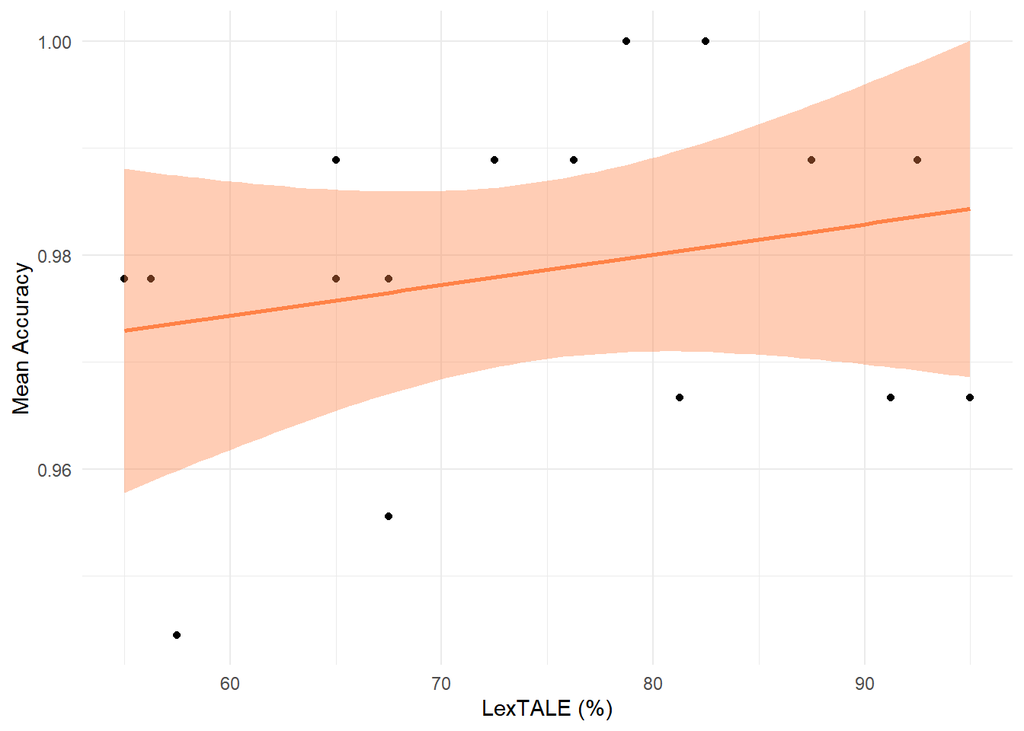

```r
# Plot
p <- ggplot(corr_df,
       aes(x = lex_tale_result, y = mean_acc)) +
  geom_point() +
  geom_smooth(method = "lm", se = TRUE, color = "sienna1", fill = "sienna1") +
  theme_minimal() +
  labs(x = "LexTALE (%)", y = "Mean Accuracy")

ggsave(
  "acc_correlation.png",
  plot = last_plot(),
  width = 7,
  height = 5
)

p
```

```r
# RT

#Pearson
cor.test(corr_df$mean_RT,
         corr_df$lex_tale_result,
         method = "pearson")
```

```
##
##  Pearson's product-moment correlation
##
## data:  corr_df$mean_RT and corr_df$lex_tale_result
## t = -1.2619, df = 14, p-value = 0.2276
## alternative hypothesis: true correlation is not equal to 0
## 95 percent confidence interval:
##  -0.7037885  0.2092860
## sample estimates:
##        cor
## -0.3195732
```

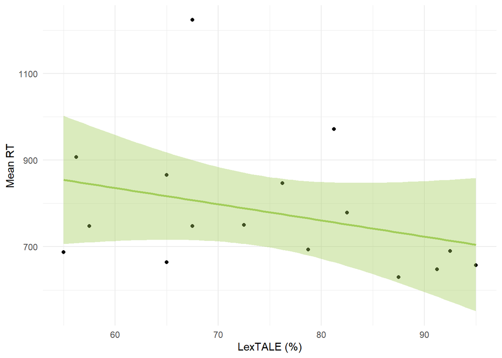

```r
# Plot
p <- ggplot(corr_df,
       aes(x = lex_tale_result, y = mean_RT)) +
  geom_point() +
  geom_smooth(method = "lm", se = TRUE, color = "darkolivegreen3", fill = "darkolivegreen3") +
  theme_minimal() +
  labs(x = "LexTALE (%)", y = "Mean RT")

ggsave(
  "RT_correlation.png",
  plot = last_plot(),
  width = 7,
  height = 5
)

p
```